# GCDS: Modeling Cognitive Task Data (Applying Supervised Learning Methods)

# 1 **Loading Libraries**

```r
library(dplyr)
library(ggplot2)
library(performance) # for parameter estimates and model performance
library(lm.beta)     # for standardized betas
#library(car)         # for ANOVA models; swap before dplyr
library(caret)       # for k-fold cross validation
library(parameters)  # for model parameters
```

# 2 **Obtain Data**

```r
#suppressMessages(source(paste(r_dir, "aggregate_STROOP.R", sep =  "/")))

STROOP <- readr::read_csv(paste(data_dir, "STROOP.csv", sep = "/"))

STROOP_agg <- readr::read_csv(paste(data_dir, "STROOP_agg.csv", sep = "/"))

completes <- STROOP_agg %>%
  select(., id) %>%
  filter(., id < 2000) %>%
  as.vector()
```

Those who completed are: 1001, 1002, 1003, 1004, 1101, 1102, 1104, 1301, 1303, 1402, 1404, 1405, 1501, 1502, 1503, 1504, 1703, 1704, 1802, 1803, 1804, 1902, 1903, 1904, 1905

# 3 **Group Level Data Summary**

```r
# Add a factor for some modeling
STROOP_agg <- STROOP_agg %>%
  mutate(., trialtype_f = factor(trialtype))

STROOP_agg_summary <- STROOP_agg %>%
  group_by(., trialtype) %>%
  summarise(.,
            mean = mean(na.omit(rt)),
            sd = sd(na.omit(rt)),
            sem = sd(na.omit(rt)) / sqrt(length(na.omit(rt))),
            n = dplyr::n() #length(na.omit(rt))
            ) %>%
  mutate(., across(where(is.numeric), round, digits = 2))

#STROOP_agg_summary %>% view(filter = "none")

STROOP_agg_summary
```

```
## # A tibble: 2 × 5
##   trialtype    mean    sd   sem     n
##   <chr>       <dbl> <dbl> <dbl> <dbl>
## 1 congruent    812.  130.  20.1    42
## 2 incongruent  977   191.  29.4    42
```

The descriptive statistics from `STROOP_agg_summary` indicate that the response time means and standard deviations (and standard errors of the mean) differ numerically across the trial types. Whether the mean response times differ enough relative to their variance is a matter or inferential statistics.

Thought Questions:

- What is the difference in means?
- Are those differences representing unsystematic variation in response times or are those differences accounted for by trial type as a predictor?
- How many standard errors (approximately) is one mean from the other mean?

Some of these questions are relevant to determining a model fitting the data.

# 4 **Fitting Simple Models**

There are two models we can run for comparison purposes. One model will use only numeric values for the predictor and another will use character strings for the predictor. You will see how the model is the same but knowing this is important.

*Model 1*: Because `ingongruent` is used to numerically specify trials as incongruent, the congruent trials are coded as 0s and the incongruent trials are coded as 1s for this variable.

*Model 2*: Using the character information of `trialtype`, incongruent and congruent trials are referenced by name rather than 0s and 1s in the previous model.

Before running either model, let’s look at a correlation matrix for these `rt` and `incongruent`. We can see that there is a positive relationship between `rt` and `incongruent`. More on this later but we know response times must be larger (slower) for incongruent compared with congruent trials.

```r
STROOP_agg %>%
  select(., rt, incongruent) %>% cor()
```

```
##                    rt incongruent
## rt          1.0000000   0.4550116
## incongruent 0.4550116   1.0000000
```

## 4.1 *Model 1*

- `lm_incongruent <- lm(rt ~ incongruent, data = STROOP_agg)`

```r
lm_incongruent <- lm(rt ~ incongruent, data = STROOP_agg)

summary(lm_incongruent)
```

```
##
## Call:
## lm(formula = rt ~ incongruent, data = STROOP_agg)
##
## Residuals:
##     Min      1Q  Median      3Q     Max
## -324.30 -129.20  -15.23  112.45  370.46
##
## Coefficients:
##             Estimate Std. Error t value Pr(>|t|)
## (Intercept)   812.29      25.17  32.271  < 2e-16 ***
## incongruent   164.71      35.60   4.627 1.37e-05 ***
## ---
## Signif. codes:  0 '***' 0.001 '**' 0.01 '*' 0.05 '.' 0.1 ' ' 1
##
## Residual standard error: 163.1 on 82 degrees of freedom
## Multiple R-squared:  0.207,  Adjusted R-squared:  0.1974
## F-statistic: 21.41 on 1 and 82 DF,  p-value: 1.371e-05
```

```r
model_parameters(lm_incongruent)
```

```
## Parameter   | Coefficient |    SE |           95% CI | t(82) |      p
## ---------------------------------------------------------------------
## (Intercept) |      812.29 | 25.17 | [762.22, 862.37] | 32.27 | < .001
## incongruent |      164.71 | 35.60 | [ 93.90, 235.53] |  4.63 | < .001
```

```
##
## Uncertainty intervals (equal-tailed) and p-values (two-tailed) computed
##   using a Wald t-distribution approximation.
```

```r
model_performance(lm_incongruent)
```

```
## # Indices of model performance
##
## AIC      |      BIC |    R2 | R2 (adj.) |    RMSE |   Sigma
## -----------------------------------------------------------
## 1098.240 | 1105.532 | 0.207 |     0.197 | 161.175 | 163.129
```

### 4.1.1 *Interpreting Intercept and Slope*

You can see that the intercept reflects the response times when `incongruent = 0` (congruent trials) and the slope reflects the change in `rt` for a unit change in `incongruent`. Moving along the predictor from 0 to 1, the slope then reflects the unit change in response time from congruent trials to incongruent trials. Although we can interpret the parameter estimates here, we will do so after standardizing the model first because doing so will help with interpreting the parameters of a more complex model.

### 4.1.2 *Standardized Coefficients of the Model*

```r
lm_incongruent_beta <- lm.beta::lm.beta(lm_incongruent)

summary(lm_incongruent_beta)
```

```
##
## Call:
## lm(formula = rt ~ incongruent, data = STROOP_agg)
##
## Residuals:
##     Min      1Q  Median      3Q     Max
## -324.30 -129.20  -15.23  112.45  370.46
##
## Coefficients:
##             Estimate Standardized Std. Error t value Pr(>|t|)
## (Intercept)  812.291           NA     25.171  32.271  < 2e-16 ***
## incongruent  164.711        0.455     35.598   4.627 1.37e-05 ***
## ---
## Signif. codes:  0 '***' 0.001 '**' 0.01 '*' 0.05 '.' 0.1 ' ' 1
##
## Residual standard error: 163.1 on 82 degrees of freedom
## Multiple R-squared:  0.207,  Adjusted R-squared:  0.1974
## F-statistic: 21.41 on 1 and 82 DF,  p-value: 1.371e-05
```

```r
model_parameters(lm_incongruent_beta)
```

```
## Parameter   | Coefficient |    SE |          95% CI | t(82) |      p
## --------------------------------------------------------------------
## incongruent |        0.46 | 35.60 | [-70.36, 71.27] | 35.60 | < .001
```

```
##
## Uncertainty intervals (equal-tailed) and p-values (two-tailed) computed
##   using a Wald t-distribution approximation.
```

```r
model_performance(lm_incongruent_beta)
```

```
## # Indices of model performance
##
## AIC      |      BIC |    R2 | R2 (adj.) |    RMSE |   Sigma
## -----------------------------------------------------------
## 1098.246 | 1105.539 | 0.207 |     0.197 | 161.175 | 162.143
```

Looking at the model parameters is the `summary()` table, notice that both raw *estimates* and *standardize estimates* are included. The `t value` represents whether the estimate differs from 0 (non-zero intercept) and is calculated as `estimate / std.error` and thus provides the *number of standard deviations the intercept (or slope) is from 0.* The corresponding p-value,`Pr(>|t|)` informs us that the intercept is significantly greater than 0 (see asterisks for flagging p values). Similarly, the t-value and p-value for the slope tells us that the slope estimate is significantly positive and non-zero. Thus, according to the model, knowing `incongruent` trial information to predict `rt` is significantly better than predicting using the mean rt when `incongruent = 0` under the mean-based model.

### 4.1.3 *Thinking about Regression*

1. What is the mean for the congruent trials?
2. How does the mean for the congruent trials compare with the intercept coefficient?
3. How does the standardized slope compare with the correlation value obtained from the earlier matrix?

## 4.2 *Model 2*

Now using `trialtype` to predict `rt`.

- `lm_trial <- lm(rt ~ trialtype, data = STROOP_agg)`

```r
lm_trial <- lm(rt ~ trialtype, data = STROOP_agg)

model_parameters(lm_trial)
```

```
## Parameter               | Coefficient |    SE |           95% CI | t(82) |      p
## ---------------------------------------------------------------------------------
## (Intercept)             |      812.29 | 25.17 | [762.22, 862.37] | 32.27 | < .001
## trialtype [incongruent] |      164.71 | 35.60 | [ 93.90, 235.53] |  4.63 | < .001
```

```
##
## Uncertainty intervals (equal-tailed) and p-values (two-tailed) computed
##   using a Wald t-distribution approximation.
```

```r
model_performance(lm_trial)
```

```
## # Indices of model performance
##
## AIC      |      BIC |    R2 | R2 (adj.) |    RMSE |   Sigma
## -----------------------------------------------------------
## 1098.240 | 1105.532 | 0.207 |     0.197 | 161.175 | 163.129
```

If you compare the model parameters for Model 1 and Model 2, you will see they are exactly the same. If curious, do a logical test, `model_parameters(lm_incongruent) == model_parameters(lm_trial)`. Importantly, the model is the same whether coded numerically or as characters.

### 4.2.1 *Standardized Coefficients of the Model*

```r
lm_trial_beta <- lm.beta::lm.beta(lm_trial)

summary(lm_trial_beta)
```

```
##
## Call:
## lm(formula = rt ~ trialtype, data = STROOP_agg)
##
## Residuals:
##     Min      1Q  Median      3Q     Max
## -324.30 -129.20  -15.23  112.45  370.46
##
## Coefficients:
##                      Estimate Standardized Std. Error t value Pr(>|t|)
## (Intercept)           812.291           NA     25.171  32.271  < 2e-16 ***
## trialtypeincongruent  164.711        0.455     35.598   4.627 1.37e-05 ***
## ---
## Signif. codes:  0 '***' 0.001 '**' 0.01 '*' 0.05 '.' 0.1 ' ' 1
##
## Residual standard error: 163.1 on 82 degrees of freedom
## Multiple R-squared:  0.207,  Adjusted R-squared:  0.1974
## F-statistic: 21.41 on 1 and 82 DF,  p-value: 1.371e-05
```

```r
model_parameters(lm_trial_beta)
```

```
## Parameter               | Coefficient |    SE |          95% CI | t(82) |      p
## --------------------------------------------------------------------------------
## trialtype [incongruent] |        0.46 | 35.60 | [-70.36, 71.27] | 35.60 | < .001
```

```r
#model_performance(lm_trial)
```

# 5 **Making Model Predictions**

General model: `y ~ b0 + b1x + ϵ`

Where:

- `x` = predictor variable
- `y` = outcome variable
- `b0` = intercept of the regression model
- `b1` = slope of the regression model
- `ϵ or e` = error term

Example: `rt ~ intercept + triatype(x)`

rt = 812.2913579 + 164.7111558 * (CongruentRt)`

Let’s review the descriptive data from before. Then using `coef()`, the model coefficients can be extracted based on their element position in the vector.

```r
STROOP_agg_summary %>%
  select(., c(trialtype, mean))
```

```
## # A tibble: 2 × 2
##   trialtype    mean
##   <chr>       <dbl>
## 1 congruent    812.
## 2 incongruent  977
```

```r
b0 <- as.numeric(coef(lm_trial)[1])  # the numeric for of the intercept coefficient

b1 <- as.numeric(coef(lm_trial)[2])  # the numeric for of the intercept coefficient
```

R is using the levels of `trialtype` in alphabetical order to determine what numeric values x should take on. Because “congruent” is earlier alphabetically, x = 0 for congruent and x = 1 for incongruent. This order makes sense in this example but if your levels don’t order alphabetically in meaningful ways, you’ll need to reorder them. Knowing whether you are predicting congruent or incongruent trial response times will be plugged into the model.

## 5.1 *Predicting by Hand*

```r
x = 0 # congruent

y = b0 + (b1 * x)
```

Thus, y = 812.2913579 + (164.7111558 * 0) = 812.2913579.

Taking the `intercept` and adding to it nothing results in predicting `rt` for congruent trials as 812.2913579 ms. This is what we predict for all congruent trials. Importantly, the error in the model (residuals) reflects the difference between the actual rt and the predicted rt (e.g., `actual rt - predicted rt`).

Now for incongruent trials…

```r
x = 1 # incongruent
y = b0 + (b1 * x)
```

Thus, y = 812.2913579 + (164.7111558 * 1) = 977.0025136.

## 5.2 *Predicting y with `predict()`*

Using `predict()`, you can make a prediction of outcome y for a given predictor x. You would pass the model so that `predict()` knows how to predict based on the parameters. You would also need to specify predictor values for which to predict y from. We will create a sample data frame for this. Because there are only two values of `trialtype` which are characters in Model 2, then we specify values as “congruent” and “incongruent” for predicting `rt` from `trialtype`.

```r
sample_trial <- data.frame(
  trialtype = c("congruent", "incongruent")
)

predict(lm_trial, newdata = sample_trial)
```

```
##        1        2
## 812.2914 977.0025
```

Notice that the model is simply predicting the mean congruent and incongruent rts based on the trial type. When your predictor is categorical, all predicted ys will be the same within a group/level. When your predictor is numeric, all predicted ys will the same within each x value (here 0 and 1). For example, when predicting height from weight, everyone who is 130 lbs will be predicted to be the same height.

If you wanted to make predictions for Model 1, there must be some changes. First, the mode is a different name, so the model passed into `predict()` must be the `lm_incongruent` model. Second, the predictor is `incongruent` with values 0 or 1, which need to be numeric. A sample data frame is:

```r
sample_incongruent <- data.frame(
  incongruent = c(0, 1)
)

predict(lm_incongruent, newdata = sample_incongruent)
```

```
##        1        2
## 812.2914 977.0025
```

## 5.3 *With Confidence or Prediction Intervals*

We can pass `interval = "confidence"` to create that interval.

```r
predict(lm_trial, newdata = sample_trial, interval = "confidence")
```

```
##        fit      lwr       upr
## 1 812.2914 762.2176  862.3651
## 2 977.0025 926.9288 1027.0762
```

We can also pass `interval = "prediction"` to create an interval for prediction.

```r
predict(lm_trial, newdata = sample_trial, interval = "prediction")
```

```
##        fit      lwr      upr
## 1 812.2914 483.9361 1140.647
## 2 977.0025 648.6472 1305.358
```

# 6 **Multiple Regression**

One problem with the `rt` data is that `rt` could be influenced by the `error` rate. A classic speed-accuracy tradeoff would be reflected in slower response times in order to keep error rate low. Plotting `error ~ rt` will reveal the relationship, if any. Not much appears going on.

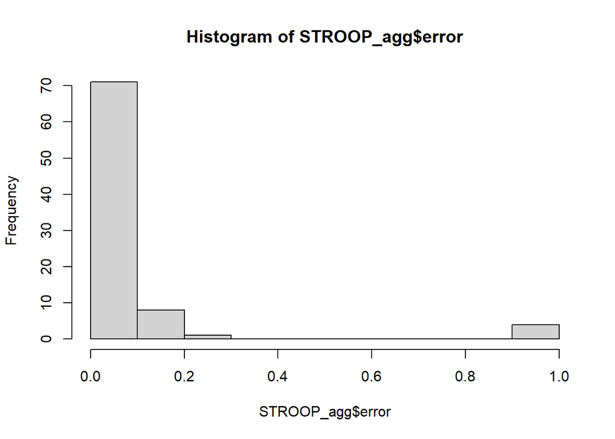

```r
hist(STROOP_agg$error)
```

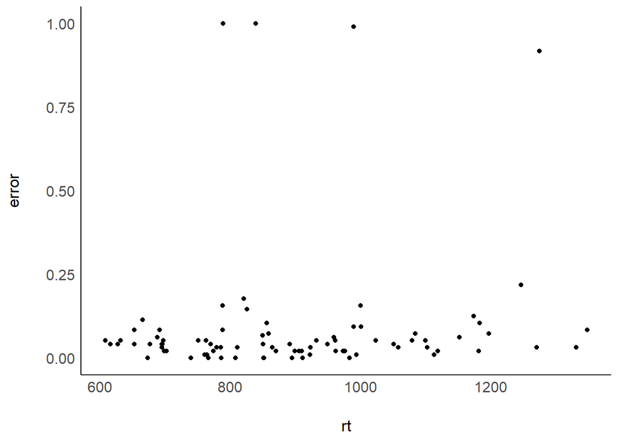

```r
ggplot(data = STROOP_agg) +
  geom_point(aes(rt, error)) +
  see::theme_modern()
```

We can approximate using Pearson’s r but you’ll notice that errors are not distributed symmetrically.

```r
STROOP_agg %>%
  select(., c(rt, error)) %>%
  cor(.) #, method = "kendall")
```

```
##             rt    error
## rt    1.000000 0.119272
## error 0.119272 1.000000
```

Any relationship may be owing to outliers serving as leverage points. Let’s remove them.

```r
STROOP_agg %>%
  filter(., error < .20) %>%
  select(., c(rt, error)) %>%
  cor(.)
```

```
##               rt      error
## rt    1.00000000 0.07275637
## error 0.07275637 1.00000000
```

## 6.1 *Holding Constant Predictor Influence*

For purposes of illustrating multiple regression, let’s just predict `rt` using both `trialtype` and `error`. Specifically, the model will provide information on the influence of `trialtype` on `rt` while holding constant `error` as well as provide information about `errors` predicting `rt` while holding constant `trialtype`.

You might be thinking that “there are different trial types though”. The regression model will hold constant the variations in `trialtype` when using `error` to predict `rt`as if the was only one trialtype. And if you are thinking “error may differ across the trialypes”, the model will control for differences in errors by making them mathematically the same in order to examine the influence of `trialtype` on `rt`.

Let’s take a closer look at that plot again first to see if `error` looks related to `trialtype`. Color code the points and add a linear fit by `trialtype` to get a better idea of how the data will be influencing the model. *Note:* Depending on the current data set, the visual linear fits may differ from a written description.

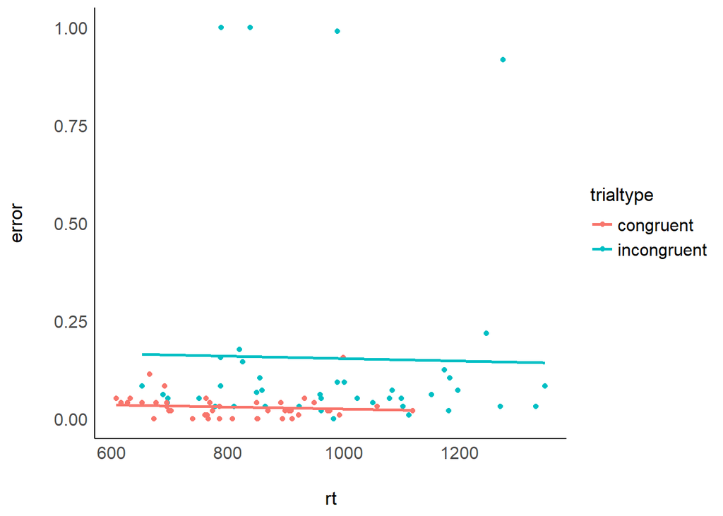

```r
ggplot(data = STROOP_agg, aes(rt, error)) +
  geom_point(aes(color = trialtype)) +
  geom_smooth(aes(color = trialtype), method = lm, se = F) +
  see::theme_modern()
```

## 6.2 *Build the Models*

*Additive Model*

```r
lm_trial_error <- STROOP_agg %>%
  lm(rt ~ trialtype + error, data = .)

model_parameters(lm_trial_error)
```

```
## Parameter               | Coefficient |    SE |            95% CI | t(81) |      p
## ----------------------------------------------------------------------------------
## (Intercept)             |      812.92 | 25.48 | [ 762.23, 863.61] | 31.91 | < .001
## trialtype [incongruent] |      167.29 | 37.64 | [  92.41, 242.18] |  4.44 | < .001
## error                   |      -20.71 | 93.06 | [-205.87, 164.45] | -0.22 | 0.824
```

```r
model_performance(lm_trial_error)
```

```
## # Indices of model performance
##
## AIC      |      BIC |    R2 | R2 (adj.) |    RMSE |   Sigma
## -----------------------------------------------------------
## 1100.189 | 1109.912 | 0.208 |     0.188 | 161.126 | 164.082
```

```r
#plot(check_outliers(lm_trial_error))
```

*Interaction Model*

Technically, to specify an interaction in R, you would use `:`, for example:

- `lm(rt ~ trialtype + error + trialtype:error)`

Using `*` in the formula will expand the model to the above form. As such, you will see many examples online using `*` instead of `:`. Both are fine.

```r
lm_trial_error_ixn <- STROOP_agg %>%
  lm(rt ~ trialtype + error + trialtype:error, data = .)

model_parameters(lm_trial_error_ixn)
```

```
## Parameter                       | Coefficient |     SE |              95% CI | t(80) |      p
## ---------------------------------------------------------------------------------------------
## (Intercept)                     |      826.30 |  35.85 | [  754.95,  897.65] | 23.05 | < .001
## trialtype [incongruent]         |      153.04 |  46.32 | [   60.87,  245.21] |  3.30 | 0.001
## error                           |     -459.21 | 828.40 | [-2107.78, 1189.37] | -0.55 | 0.581
## trialtype [incongruent] * error |      444.15 | 833.73 | [-1215.02, 2103.33] |  0.53 | 0.596
```

```
##
## Uncertainty intervals (equal-tailed) and p-values (two-tailed) computed
##   using a Wald t-distribution approximation.
```

```r
model_performance(lm_trial_error_ixn)
```

```
## # Indices of model performance
##
## AIC      |      BIC |    R2 | R2 (adj.) |    RMSE |   Sigma
## -----------------------------------------------------------
## 1101.891 | 1114.045 | 0.210 |     0.181 | 160.841 | 164.813
```

```r
#plot(check_outliers(lm_trial_error_ixn))
```

## 6.3 *Obtain the Standardized Coefficients*

```r
lm_trial_error_beta <- lm.beta::lm.beta(lm_trial_error)

lm_trial_error_ixn_beta <- lm.beta::lm.beta(lm_trial_error_ixn)

model_parameters(lm_trial_error_beta)
```

```
## Parameter               | Coefficient |    SE |            95% CI | t(81) |      p
## ----------------------------------------------------------------------------------
## trialtype [incongruent] |        0.46 | 37.64 | [ -74.42,  75.35] | 37.64 | < .001
## error                   |       -0.02 | 93.06 | [-185.18, 185.14] | 93.06 | < .001
```

```r
model_parameters(lm_trial_error_ixn_beta)
```

```
## Parameter                       | Coefficient |     SE |              95% CI |  t(80) |      p
## ----------------------------------------------------------------------------------------------
## trialtype [incongruent]         |        0.42 |  46.32 | [  -91.75,   92.59] |  46.32 | < .001
## error                           |       -0.51 | 828.40 | [-1649.09, 1648.07] | 828.40 | < .001
## trialtype [incongruent] * error |        0.51 | 833.73 | [-1658.67, 1659.68] | 833.73 | < .001
```

Notice how introducing `error` into the model, the slope for `trialtype` (may) change but also that the standard error (e.g., `SE`) may also change and corresponding confidence interval may cover a larger range of values, suggesting less certainty. The slope for `error` may be negative.

```r
compare_performance(lm_trial_beta, lm_trial_error_beta, rank = T)
```

```
## # Comparison of Model Performance Indices
##
## Name                |   Model |    R2 | R2 (adj.) |    RMSE |   Sigma | AIC weights | BIC weights | Performance-Score
## ---------------------------------------------------------------------------------------------------------------------
## lm_trial_beta       | lm.beta | 0.207 |     0.197 | 161.175 | 162.143 |       0.726 |       0.899 |            66.67%
## lm_trial_error_beta | lm.beta | 0.208 |     0.188 | 161.126 | 163.079 |       0.274 |       0.101 |            33.33%
```

Notice the ranking. The *adjusted R2* is slightly higher for the simple model even though R2 is lowest for that model. Although the `R2` value is higher, it’s not much higher. Similarly, `RMSE` also does not differ much by adding this second predictor. Remember, that the model provides point estimates along with error measures for confidence intervals. There are more advanced ways to evaluate model accuracy that involves some training assessments.

# 7 **Model Accuracy Using k-fold Cross-Validation (kFCV)**

Using `caret::train()`, we can train the model using k-fold cross-validation. The function will return a cross-validated RMSE for both model accuracy and for comparing models. The data will essentially be split into k different samples (“folds”) and the model will be run on each sample. The k-models will be averaged and combined for comparisons.

We will use k-fold cross validation for both the simple model and the more complex one. In order to replicate the outcome, let’s first set a random seed so the results will be the same.

```r
set.seed(131)

lm_trial_cv <- caret::train(
  rt ~ trialtype,
  data = STROOP_agg,
  method = "lm",
  trControl = trainControl(method = "cv", number = 10)
  )

lm_trial_error_cv <- caret::train(
  rt ~ trialtype + error,
  data = STROOP_agg,
  method = "lm",
  trControl = trainControl(method = "cv", number = 10)
  )

lm_trial_error_ixn_cv <- caret::train(
  rt ~ trialtype + error + trialtype:error,
  data = STROOP_agg,
  method = "lm",
  trControl = trainControl(method = "cv", number = 10)
  )
```

## 7.1 *Extract the Model*

Using `caret::resamples()`, we can specify a `list()` object holding the models. We will assign each model a name too just to make output easier to read.

```r
mod_resamples <- caret::resamples(
  list(
    trial = lm_trial_cv,
    trial_e = lm_trial_error_cv,
    trial_e_ixn = lm_trial_error_ixn_cv
  )
)
```

## 7.2 *Compare RMSE and R2*

We will now take a look at the cross-validated `R2` and `RMSE`’s for all three models. AIC and BIC weights are not included.

```r
# new estimates using k-fold cross-validation
summary(mod_resamples)
```

```
##
## Call:
## summary.resamples(object = mod_resamples)
##
## Models: trial, trial_e, trial_e_ixn
## Number of resamples: 10
##
## MAE
##                  Min.  1st Qu.   Median     Mean  3rd Qu.     Max. NA's
## trial        93.87643 114.5726 131.9668 136.9365 159.5324 185.4527    0
## trial_e     107.56673 131.9497 138.7572 141.3070 147.7533 192.0354    0
## trial_e_ixn 112.38858 121.6191 133.4732 139.8500 147.6030 211.7252    0
##
## RMSE
##                 Min.  1st Qu.   Median     Mean  3rd Qu.     Max. NA's
## trial       116.7609 141.0568 160.6321 160.9823 180.0949 203.2148    0
## trial_e     124.3204 154.8247 166.5636 167.8747 177.8288 227.2499    0
## trial_e_ixn 139.3233 144.8933 166.6124 168.6560 179.9605 231.8601    0
##
## Rsquared
##                     Min.    1st Qu.    Median      Mean   3rd Qu.      Max.
## trial       0.0003591418 0.10934611 0.2718791 0.2627528 0.3470269 0.6247701
## trial_e     0.0084115329 0.11658206 0.2138231 0.2671705 0.4265801 0.6118278
## trial_e_ixn 0.0100637387 0.07205574 0.1439866 0.2580838 0.3676712 0.7443615
##             NA's
## trial          0
## trial_e        0
## trial_e_ixn    0
```